```python
import pandas as pd
import numpy as np
import matplotlib.pyplot as plt
%matplotlib inline
import seaborn as sns
from sklearn.linear_model import LogisticRegression
from sklearn.tree import DecisionTreeClassifier
from sklearn.ensemble import RandomForestClassifier
from sklearn.neighbors import KNeighborsClassifier
from sklearn.naive_bayes import GaussianNB as gnb
from sklearn.model_selection import cross_val_score
from sklearn.model_selection import train_test_split
from sklearn.metrics import accuracy_score, confusion_matrix
from sklearn import tree
from os import system
from sklearn.metrics import roc_auc_score
from sklearn.metrics import roc_curve
# Suppressing Warnings
import warnings
warnings.filterwarnings('ignore')
```

# 1. Load the dataset

```python
#importing csv data and view data
data=pd.read_csv("Data")
data.head()
```

|  | name | MDVP:Fo(Hz) | MDVP:Fhi(Hz) | MDVP:Flo(Hz) | MDVP:Jitter(%) | MDVP:Jitter(Abs) | MDVP:RAP | MDVP:PPQ | Jitter:DDP | MDVP:Shimmer | ... | Shimmer:DDA | NHR | HNR | status | RPDE | DFA | spread1 | spread2 | D2 | PPE |
| --- | --- | --- | --- | --- | --- | --- | --- | --- | --- | --- | --- | --- | --- | --- | --- | --- | --- | --- | --- | --- | --- |
| 0 | phon_R01_S01_1 | 119.992 | 157.302 | 74.997 | 0.00784 | 0.00007 | 0.00370 | 0.00554 | 0.01109 | 0.04374 | ... | 0.06545 | 0.02211 | 21.033 | 1 | 0.414783 | 0.815285 | -4.813031 | 0.266482 | 2.301442 | 0.284654 |
| 1 | phon_R01_S01_2 | 122.400 | 148.650 | 113.819 | 0.00968 | 0.00008 | 0.00465 | 0.00696 | 0.01394 | 0.06134 | ... | 0.09403 | 0.01929 | 19.085 | 1 | 0.458359 | 0.819521 | -4.075192 | 0.335590 | 2.486855 | 0.368674 |
| 2 | phon_R01_S01_3 | 116.682 | 131.111 | 111.555 | 0.01050 | 0.00009 | 0.00544 | 0.00781 | 0.01633 | 0.05233 | ... | 0.08270 | 0.01309 | 20.651 | 1 | 0.429895 | 0.825288 | -4.443179 | 0.311173 | 2.342259 | 0.332634 |
| 3 | phon_R01_S01_4 | 116.676 | 137.871 | 111.366 | 0.00997 | 0.00009 | 0.00502 | 0.00698 | 0.01505 | 0.05492 | ... | 0.08771 | 0.01353 | 20.644 | 1 | 0.434969 | 0.819235 | -4.117501 | 0.334147 | 2.405554 | 0.368975 |
| 4 | phon_R01_S01_5 | 116.014 | 141.781 | 110.655 | 0.01284 | 0.00011 | 0.00655 | 0.00908 | 0.01966 | 0.06425 | ... | 0.10470 | 0.01767 | 19.649 | 1 | 0.417356 | 0.823484 | -3.747787 | 0.234513 | 2.332180 | 0.410335 |

5 rows × 24 columns

# 2. It is always a good practice to eye-ball raw data to get a feel of the data in terms of number of records, structure of the file, number of attributes, tyes of attributes and a general idea of likely challenges in the dataset. Mention a few comments in this regard (5 points)

```python
#chec
data.shape
```

```
(195, 24)
```

```python
data.dtypes
```

```
name                 object
MDVP:Fo(Hz)         float64
MDVP:Fhi(Hz)        float64
MDVP:Flo(Hz)        float64
MDVP:Jitter(%)      float64
MDVP:Jitter(Abs)    float64
MDVP:RAP            float64
MDVP:PPQ            float64
Jitter:DDP          float64
MDVP:Shimmer        float64
MDVP:Shimmer(dB)    float64
Shimmer:APQ3        float64
Shimmer:APQ5        float64
MDVP:APQ            float64
Shimmer:DDA         float64
NHR                 float64
HNR                 float64
status                int64
RPDE                float64
DFA                 float64
spread1             float64
spread2             float64
D2                  float64
PPE                 float64
dtype: object
```

```python
#checking blanks, there are no blanks in data
data.isnull().sum()
```

```
name                0
MDVP:Fo(Hz)         0
MDVP:Fhi(Hz)        0
MDVP:Flo(Hz)        0
MDVP:Jitter(%)      0
MDVP:Jitter(Abs)    0
MDVP:RAP            0
MDVP:PPQ            0
Jitter:DDP          0
MDVP:Shimmer        0
MDVP:Shimmer(dB)    0
Shimmer:APQ3        0
Shimmer:APQ5        0
MDVP:APQ            0
Shimmer:DDA         0
NHR                 0
HNR                 0
status              0
RPDE                0
DFA                 0
spread1             0
spread2             0
D2                  0
PPE                 0
dtype: int64
```

```python
#Moving status column to the last
df=data.pop('status')
data['status'] = df
```

```python
data.describe().transpose()
```

|  | count | mean | std | min | 25% | 50% | 75% | max |
| --- | --- | --- | --- | --- | --- | --- | --- | --- |
| MDVP:Fo(Hz) | 195.0 | 154.228641 | 41.390065 | 88.333000 | 117.572000 | 148.790000 | 182.769000 | 260.105000 |
| MDVP:Fhi(Hz) | 195.0 | 197.104918 | 91.491548 | 102.145000 | 134.862500 | 175.829000 | 224.205500 | 592.030000 |
| MDVP:Flo(Hz) | 195.0 | 116.324631 | 43.521413 | 65.476000 | 84.291000 | 104.315000 | 140.018500 | 239.170000 |
| MDVP:Jitter(%) | 195.0 | 0.006220 | 0.004848 | 0.001680 | 0.003460 | 0.004940 | 0.007365 | 0.033160 |
| MDVP:Jitter(Abs) | 195.0 | 0.000044 | 0.000035 | 0.000007 | 0.000020 | 0.000030 | 0.000060 | 0.000260 |
| MDVP:RAP | 195.0 | 0.003306 | 0.002968 | 0.000680 | 0.001660 | 0.002500 | 0.003835 | 0.021440 |
| MDVP:PPQ | 195.0 | 0.003446 | 0.002759 | 0.000920 | 0.001860 | 0.002690 | 0.003955 | 0.019580 |
| Jitter:DDP | 195.0 | 0.009920 | 0.008903 | 0.002040 | 0.004985 | 0.007490 | 0.011505 | 0.064330 |
| MDVP:Shimmer | 195.0 | 0.029709 | 0.018857 | 0.009540 | 0.016505 | 0.022970 | 0.037885 | 0.119080 |
| MDVP:Shimmer(dB) | 195.0 | 0.282251 | 0.194877 | 0.085000 | 0.148500 | 0.221000 | 0.350000 | 1.302000 |
| Shimmer:APQ3 | 195.0 | 0.015664 | 0.010153 | 0.004550 | 0.008245 | 0.012790 | 0.020265 | 0.056470 |
| Shimmer:APQ5 | 195.0 | 0.017878 | 0.012024 | 0.005700 | 0.009580 | 0.013470 | 0.022380 | 0.079400 |
| MDVP:APQ | 195.0 | 0.024081 | 0.016947 | 0.007190 | 0.013080 | 0.018260 | 0.029400 | 0.137780 |
| Shimmer:DDA | 195.0 | 0.046993 | 0.030459 | 0.013640 | 0.024735 | 0.038360 | 0.060795 | 0.169420 |
| NHR | 195.0 | 0.024847 | 0.040418 | 0.000650 | 0.005925 | 0.011660 | 0.025640 | 0.314820 |
| HNR | 195.0 | 21.885974 | 4.425764 | 8.441000 | 19.198000 | 22.085000 | 25.075500 | 33.047000 |
| RPDE | 195.0 | 0.498536 | 0.103942 | 0.256570 | 0.421306 | 0.495954 | 0.587562 | 0.685151 |
| DFA | 195.0 | 0.718099 | 0.055336 | 0.574282 | 0.674758 | 0.722254 | 0.761881 | 0.825288 |
| spread1 | 195.0 | -5.684397 | 1.090208 | -7.964984 | -6.450096 | -5.720868 | -5.046192 | -2.434031 |
| spread2 | 195.0 | 0.226510 | 0.083406 | 0.006274 | 0.174351 | 0.218885 | 0.279234 | 0.450493 |
| D2 | 195.0 | 2.381826 | 0.382799 | 1.423287 | 2.099125 | 2.361532 | 2.636456 | 3.671155 |
| PPE | 195.0 | 0.206552 | 0.090119 | 0.044539 | 0.137451 | 0.194052 | 0.252980 | 0.527367 |
| status | 195.0 | 0.753846 | 0.431878 | 0.000000 | 1.000000 | 1.000000 | 1.000000 | 1.000000 |

```python
# There are 147 people affected with PD
data.status.value_counts()
```

```
1    147
0     48
Name: status, dtype: int64
```

# 3. Using univariate & bivariate analysis to check the individual attributes for their basic statistics such as central values, spread, tails, relationships between variables etc. mention your observations (15 points)

# Univariate Analysis

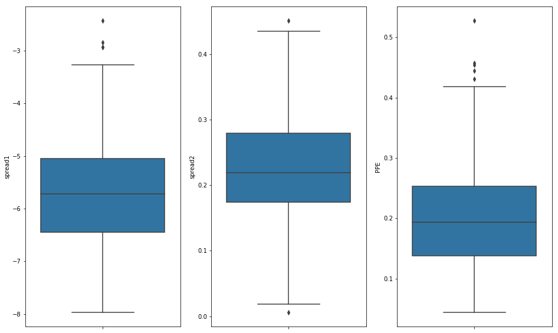

```python
fig, ax = plt.subplots(1,3,figsize=(16,10))
sns.boxplot(x='spread1',data=data, ax=ax[0],orient='v')
sns.boxplot(x='spread2',data=data, ax=ax[1],orient='v')
sns.boxplot(x='PPE',data=data,ax=ax[2],orient='v')
```

The above figure shows the box plot of the frequency variation. All the three variations have outliers. Generally speaking, decision trees are able to handle outliers. It is very unlikely that decision tree will create a leaf to isolate them

```python
# dropping name column as this column is not much significant
data = data.drop('name',axis=1)
```

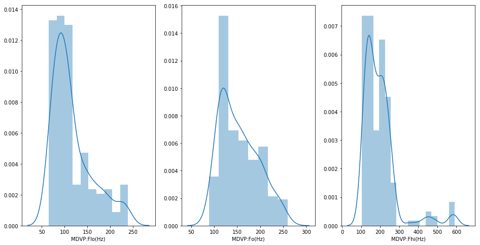

```python
fig, ax = plt.subplots(1,3,figsize=(16,8))
sns.distplot(data['MDVP:Flo(Hz)'],ax=ax[0])
sns.distplot(data['MDVP:Fo(Hz)'],ax=ax[1])
sns.distplot(data['MDVP:Fhi(Hz)'],ax=ax[2])
```

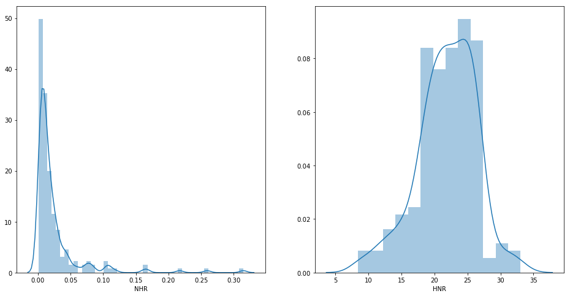

```python
fig, ax = plt.subplots(1,2,figsize=(16,8))
sns.distplot(data['NHR'],ax=ax[0])
sns.distplot(data['HNR'],ax=ax[1])
```

The measure of tonal component of frequency is shown above. The value NHR is right skewed for there are so many observations in the area, but they seem to be with very minimal values. The maximum number of observations is between 0 and 0.04. The value HNR looks like normally distributed, but in a first look there seems to be a slight negative skewness

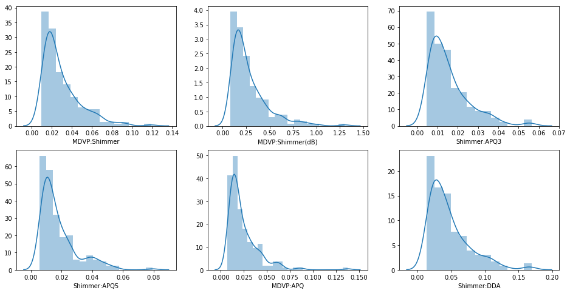

```python
fig, ax = plt.subplots(2,3,figsize=(16,8))
sns.distplot(data['MDVP:Shimmer'],ax=ax[0,0])
sns.distplot(data['MDVP:Shimmer(dB)'],ax=ax[0,1])
sns.distplot(data['Shimmer:APQ3'],ax=ax[0,2])
sns.distplot(data['Shimmer:APQ5'],ax=ax[1,0])
sns.distplot(data['MDVP:APQ'],ax=ax[1,1])
sns.distplot(data['Shimmer:DDA'],ax=ax[1,2])
```

For all of the above graphs, we can observe that the measure of variation in amplitude is positively skewed

# Bi -Variate Analysis

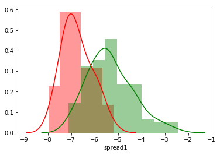

```python
sns.distplot( data[data.status == 0]['spread1'], color = 'r')
sns.distplot( data[data.status == 1]['spread1'], color = 'g')
```

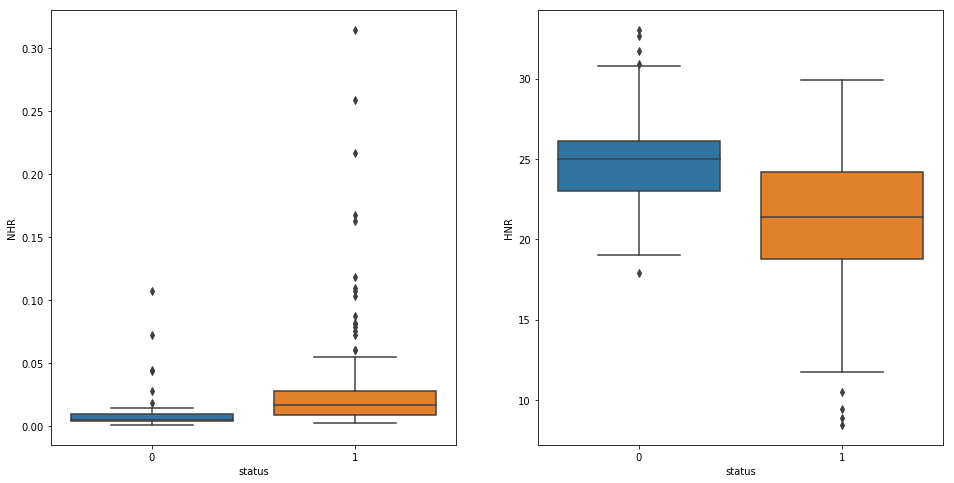

```python
fig, ax = plt.subplots(1,2,figsize=(16,8))
sns.boxplot(x='status',y='NHR',data=data,ax=ax[0])
sns.boxplot(x='status',y='HNR',data=data,ax=ax[1])
```

People who have PD(status equal to one) have higher levels of Noise to Harmonic ratio. Also, looking into the HNR ratio people who have PD have lower levels in the same.

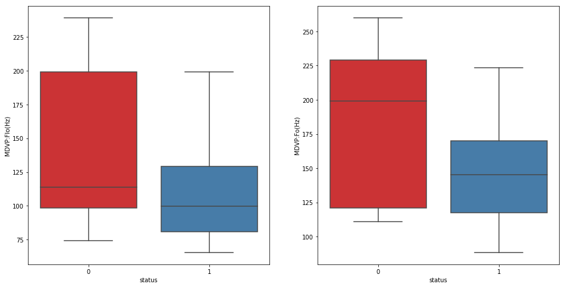

```python
fig, ax = plt.subplots(1,2,figsize=(16,8))
sns.boxplot(x='status',y='MDVP:Flo(Hz)',data=data,palette="Set1",ax=ax[0])
sns.boxplot(x='status',y='MDVP:Fo(Hz)',data=data,palette="Set1",ax=ax[1])
```

When we look the relationship between status and MDVP:Fo(Hz) we can see the median value is around 199 Hz for people who are normal. For people who are affected with Parkinsons the median value comes around 145 Hz

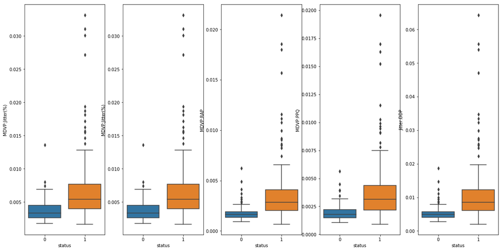

```python
# For categorical predictors
cols = ["MDVP:Jitter(%)","MDVP:Jitter(%)","MDVP:RAP","MDVP:PPQ","Jitter:DDP"]
fig, axs = plt.subplots(ncols = 5,figsize=(16,8))
fig.tight_layout()
for i in range(0,len(cols)):
    sns.boxplot(x='status',y=cols[i],data=data, ax = axs[i])
```

# Correlation comparision with heat map

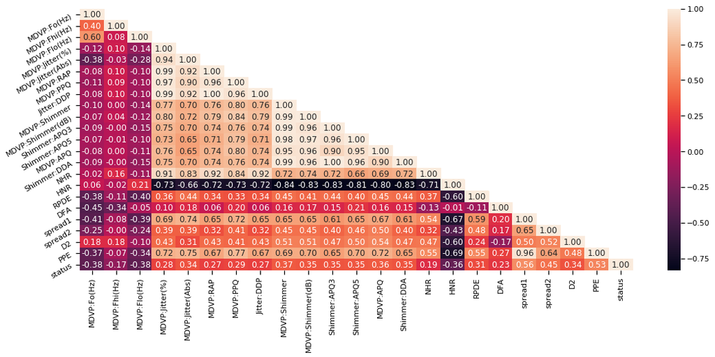

```python
corr = data.corr()
sns.set_context("notebook", font_scale=1.0, rc={"lines.linewidth": 3.5})
plt.figure(figsize=(18,7))
# create a mask so we only see the correlation values once
mask = np.zeros_like(corr)
mask[np.triu_indices_from(mask, 1)] = True
a = sns.heatmap(corr,mask=mask, annot=True, fmt='.2f')
rotx = a.set_xticklabels(a.get_xticklabels(), rotation=90)
roty = a.set_yticklabels(a.get_yticklabels(), rotation=30)
```

# 4. Split the dataset into training and test set in the ratio of 70:30 (Training:Test) (5 points)

```python
from sklearn import metrics
```

```python
X = data.drop("status",axis=1)
Y = data["status"]
```

```python
# Splitting Data into 70% Training data and 30% Testing Data:
X_train, X_test, y_train,  y_test = train_test_split(X, Y,train_size=0.7, test_size=0.3, random_state=42)
print(len(X_train)),print(len(X_test))
```

```
136
59
```

```
(None, None)
```

# 5. Prepare the data for training - Scale the data if necessary, get rid of missing values (if any) etc (5 points)

There are no missing values as per analysis in the data analysis Scaling is not necessary here since all the feature variables are continous

# 6. Train at least 3 standard classification algorithms - Logistic Regression, Naive Bayes’, SVM, k-NN etc, and note down their accuracies on the test data (10 points)

# Logistic Regression

```python
classifier = LogisticRegression(random_state = 0)
classifier.fit(X_train, y_train)
print("Accuracy of Logistic regression model :",classifier.score(X_test , y_test))
```

```
Accuracy of Logistic regression model : 0.8305084745762712
```

```python
y_pred = classifier.predict(X_test)
confusion_matrix(y_test,y_pred)
```

```
array([[ 8,  7],
       [ 3, 41]], dtype=int64)
```

```python
array=confusion_matrix(y_test,y_pred)
TP=confusion_matrix(y_test,y_pred)[0][0]
TN=confusion_matrix(y_test,y_pred)[1][1]
FP=confusion_matrix(y_test,y_pred)[0][1]
FN=confusion_matrix(y_test,y_pred)[1][0]
Accuracy=(TP+TN)/(TP+TN+FP+FN)
print('Accuracy of logistic regression classifier on test set: {:.2%}'.format(Accuracy))

Misclassification_Rate=(FP+FN)/(TP+TN+FP+FN)
print('Misclassification Rate: It is often wrong: {:.2%}'.format(Misclassification_Rate))

#Recall
Sensitivity=TP/(FN+TP)
print('Sensitivity: When its actually yes how often it predicts yes: {:.2%}'.format(Sensitivity))

Specificity=TN/(TN+FP)
print('Specificity: When its actually no, how often does it predict no: {:.2%}'.format(Specificity))

Precision=TP/(FP+TP)
print('Precision: When it predicts yes, how often is it correct: {:.2%}'.format(Precision))
```

```
Accuracy of logistic regression classifier on test set: 83.05%
Misclassification Rate: It is often wrong: 16.95%
Sensitivity: When its actually yes how often it predicts yes: 72.73%
Specificity: When its actually no, how often does it predict no: 85.42%
Precision: When it predicts yes, how often is it correct: 53.33%
```

# Naive Bayes

```python
from sklearn.naive_bayes import GaussianNB
gnb = GaussianNB()
gnb.fit(X_train, y_train)
```

```
GaussianNB()
```

```python
y_pred = gnb.predict(X_test)
confusion_matrix(y_test,y_pred)
```

```
array([[12,  3],
       [12, 32]], dtype=int64)
```

```python
array=confusion_matrix(y_test,y_pred)
TP=confusion_matrix(y_test,y_pred)[0][0]
TN=confusion_matrix(y_test,y_pred)[1][1]
FP=confusion_matrix(y_test,y_pred)[0][1]
FN=confusion_matrix(y_test,y_pred)[1][0]
Accuracy=(TP+TN)/(TP+TN+FP+FN)
print('Accuracy of logistic regression classifier on test set: {:.2%}'.format(Accuracy))

Misclassification_Rate=(FP+FN)/(TP+TN+FP+FN)
print('Misclassification Rate: It is often wrong: {:.2%}'.format(Misclassification_Rate))

#Recall
Sensitivity=TP/(FN+TP)
print('Sensitivity: When its actually yes how often it predicts yes: {:.2%}'.format(Sensitivity))

Specificity=TN/(TN+FP)
print('Specificity: When its actually no, how often does it predict no: {:.2%}'.format(Specificity))

Precision=TP/(FP+TP)
print('Precision: When it predicts yes, how often is it correct: {:.2%}'.format(Precision))
```

```
Accuracy of logistic regression classifier on test set: 74.58%
Misclassification Rate: It is often wrong: 25.42%
Sensitivity: When its actually yes how often it predicts yes: 50.00%
Specificity: When its actually no, how often does it predict no: 91.43%
Precision: When it predicts yes, how often is it correct: 80.00%
```

# SVM

```python
from sklearn import svm
svmc = svm.SVC()
svmc.fit(X_train, y_train)
```

```
SVC()
```

```python
y_pred = svmc.predict(X_test)
confusion_matrix(y_test,y_pred)
```

```
array([[ 4, 11],
       [ 0, 44]], dtype=int64)
```

```python
array=confusion_matrix(y_test,y_pred)
TP=confusion_matrix(y_test,y_pred)[0][0]
TN=confusion_matrix(y_test,y_pred)[1][1]
FP=confusion_matrix(y_test,y_pred)[0][1]
FN=confusion_matrix(y_test,y_pred)[1][0]
Accuracy=(TP+TN)/(TP+TN+FP+FN)
print('Accuracy of svm  classifier on test set: {:.2%}'.format(Accuracy))

Misclassification_Rate=(FP+FN)/(TP+TN+FP+FN)
print('Misclassification Rate: It is often wrong: {:.2%}'.format(Misclassification_Rate))

#Recall
Sensitivity=TP/(FN+TP)
print('Sensitivity: When its actually yes how often it predicts yes: {:.2%}'.format(Sensitivity))

Specificity=TN/(TN+FP)
print('Specificity: When its actually no, how often does it predict no: {:.2%}'.format(Specificity))

Precision=TP/(FP+TP)
print('Precision: When it predicts yes, how often is it correct: {:.2%}'.format(Precision))
```

```
Accuracy of svm  classifier on test set: 81.36%
Misclassification Rate: It is often wrong: 18.64%
Sensitivity: When its actually yes how often it predicts yes: 100.00%
Specificity: When its actually no, how often does it predict no: 80.00%
Precision: When it predicts yes, how often is it correct: 26.67%
```

# k-NN

```python
from sklearn.neighbors import KNeighborsClassifier
model = KNeighborsClassifier(n_neighbors=3)
model.fit(X_train,y_train)
```

```
KNeighborsClassifier(n_neighbors=3)
```

```python
y_pred = model.predict(X_test)
confusion_matrix(y_test,y_pred)
```

```
array([[ 9,  6],
       [ 6, 38]], dtype=int64)
```

```python
array=confusion_matrix(y_test,y_pred)
TP=confusion_matrix(y_test,y_pred)[0][0]
TN=confusion_matrix(y_test,y_pred)[1][1]
FP=confusion_matrix(y_test,y_pred)[0][1]
FN=confusion_matrix(y_test,y_pred)[1][0]
Accuracy=(TP+TN)/(TP+TN+FP+FN)
print('Accuracy of knn  classifier on test set: {:.2%}'.format(Accuracy))

Misclassification_Rate=(FP+FN)/(TP+TN+FP+FN)
print('Misclassification Rate: It is often wrong: {:.2%}'.format(Misclassification_Rate))

#Recall
Sensitivity=TP/(FN+TP)
print('Sensitivity: When its actually yes how often it predicts yes: {:.2%}'.format(Sensitivity))

Specificity=TN/(TN+FP)
print('Specificity: When its actually no, how often does it predict no: {:.2%}'.format(Specificity))

Precision=TP/(FP+TP)
print('Precision: When it predicts yes, how often is it correct: {:.2%}'.format(Precision))
```

```
Accuracy of knn  classifier on test set: 79.66%
Misclassification Rate: It is often wrong: 20.34%
Sensitivity: When its actually yes how often it predicts yes: 60.00%
Specificity: When its actually no, how often does it predict no: 86.36%
Precision: When it predicts yes, how often is it correct: 60.00%
```

# 7. Train a meta-classifier and note the accuracy on test data (10 points)

```python
from sklearn.ensemble import StackingClassifier
models = [('lr',LogisticRegression()),('svm',svm.SVC())]
stacking = StackingClassifier(estimators=models)
stacking.fit(X_train,y_train)
```

```
StackingClassifier(estimators=[('lr', LogisticRegression()), ('svm', SVC())])
```

```python
y_pred = stacking.predict(X_test)
confusion_matrix(y_test,y_pred)
```

```
array([[ 7,  8],
       [ 1, 43]], dtype=int64)
```

```python
array=confusion_matrix(y_test,y_pred)
TP=confusion_matrix(y_test,y_pred)[0][0]
TN=confusion_matrix(y_test,y_pred)[1][1]
FP=confusion_matrix(y_test,y_pred)[0][1]
FN=confusion_matrix(y_test,y_pred)[1][0]
Accuracy=(TP+TN)/(TP+TN+FP+FN)
print('Accuracy of stacking classifier on test set: {:.2%}'.format(Accuracy))

Misclassification_Rate=(FP+FN)/(TP+TN+FP+FN)
print('Misclassification Rate: It is often wrong: {:.2%}'.format(Misclassification_Rate))

#Recall
Sensitivity=TP/(FN+TP)
print('Sensitivity: When its actually yes how often it predicts yes: {:.2%}'.format(Sensitivity))

Specificity=TN/(TN+FP)
print('Specificity: When its actually no, how often does it predict no: {:.2%}'.format(Specificity))

Precision=TP/(FP+TP)
print('Precision: When it predicts yes, how often is it correct: {:.2%}'.format(Precision))
```

```
Accuracy of stacking classifier on test set: 84.75%
Misclassification Rate: It is often wrong: 15.25%
Sensitivity: When its actually yes how often it predicts yes: 87.50%
Specificity: When its actually no, how often does it predict no: 84.31%
Precision: When it predicts yes, how often is it correct: 46.67%
```

# 8. Train at least one standard Ensemble model - Random forest, Bagging, Boosting etc, and note the accuracy (10 points)

```python
from sklearn.ensemble import RandomForestClassifier
clf=RandomForestClassifier(n_estimators=100)
clf.fit(X_train,y_train)
```

```
RandomForestClassifier()
```

```python
y_pred = clf.predict(X_test)
confusion_matrix(y_test,y_pred)
```

```
array([[11,  4],
       [ 1, 43]], dtype=int64)
```

```python
array=confusion_matrix(y_test,y_pred)
TP=confusion_matrix(y_test,y_pred)[0][0]
TN=confusion_matrix(y_test,y_pred)[1][1]
FP=confusion_matrix(y_test,y_pred)[0][1]
FN=confusion_matrix(y_test,y_pred)[1][0]
Accuracy=(TP+TN)/(TP+TN+FP+FN)
print('Accuracy of random forest classifier on test set: {:.2%}'.format(Accuracy))

Misclassification_Rate=(FP+FN)/(TP+TN+FP+FN)
print('Misclassification Rate: It is often wrong: {:.2%}'.format(Misclassification_Rate))

#Recall
Sensitivity=TP/(FN+TP)
print('Sensitivity: When its actually yes how often it predicts yes: {:.2%}'.format(Sensitivity))

Specificity=TN/(TN+FP)
print('Specificity: When its actually no, how often does it predict no: {:.2%}'.format(Specificity))

Precision=TP/(FP+TP)
print('Precision: When it predicts yes, how often is it correct: {:.2%}'.format(Precision))
```

```
Accuracy of random forest classifier on test set: 91.53%
Misclassification Rate: It is often wrong: 8.47%
Sensitivity: When its actually yes how often it predicts yes: 91.67%
Specificity: When its actually no, how often does it predict no: 91.49%
Precision: When it predicts yes, how often is it correct: 73.33%
```

# 9. Compare all the models (minimum 5) and pick the best one among them (10 points)

```python
# Logistic regression
# Accuracy of logistic regression classifier on test set: 83.05%
# Misclassification Rate: It is often wrong: 16.95%
# Sensitivity: When its actually yes how often it predicts yes: 72.73%
# Specificity: When its actually no, how often does it predict no: 85.42%
# Precision: When it predicts yes, how often is it correct: 53.33%

# Naive bayes
# Accuracy of logistic regression classifier on test set: 74.58%
# Misclassification Rate: It is often wrong: 25.42%
# Sensitivity: When its actually yes how often it predicts yes: 50.00%
# Specificity: When its actually no, how often does it predict no: 91.43%
# Precision: When it predicts yes, how often is it correct: 80.00%


# SVM
# Accuracy of logistic regression classifier on test set: 81.36%
# Misclassification Rate: It is often wrong: 18.64%
# Sensitivity: When its actually yes how often it predicts yes: 100.00%
# Specificity: When its actually no, how often does it predict no: 80.00%
# Precision: When it predicts yes, how often is it correct: 26.67%

# KNN
# Accuracy of logistic regression classifier on test set: 79.66%
# Misclassification Rate: It is often wrong: 20.34%
# Sensitivity: When its actually yes how often it predicts yes: 60.00%
# Specificity: When its actually no, how often does it predict no: 86.36%
# Precision: When it predicts yes, how often is it correct: 60.00%

# Stacking
# Accuracy of logistic regression classifier on test set: 84.75%
# Misclassification Rate: It is often wrong: 15.25%
# Sensitivity: When its actually yes how often it predicts yes: 87.50%
# Specificity: When its actually no, how often does it predict no: 84.31%
# Precision: When it predicts yes, how often is it correct: 46.67%

# Random forest
# Accuracy of logistic regression classifier on test set: 91.53%
# Misclassification Rate: It is often wrong: 8.47%
# Sensitivity: When its actually yes how often it predicts yes: 91.67%
# Specificity: When its actually no, how often does it predict no: 91.49%
# Precision: When it predicts yes, how often is it correct: 73.33%
```